# Psychological quality of life in Brazilian medical students

Dataset 8: Resilience, learning environment and quality of life in Brazilian medical students

RSR feasibility analysis

2026-08-03

# Introduction

Tempski and colleagues surveyed a random sample of 1,350 students at 22 Brazilian medical schools in 2011-2012, measuring quality of life (WHOQOL-BREF), the perceived educational environment (DREEM), resilience, depressive symptoms and anxiety in a single cross-sectional questionnaire (Tempski et al., *PLOS ONE* 2015; doi:10.1371/journal.pone.0131535). The psychological domain of the WHOQOL-BREF - positive and negative feelings, self-esteem, concentration, body image and meaning in life - is the domain most consistently depressed in medical trainees, and was the paper’s primary quality-of-life outcome.

**Aim.** Among Brazilian medical students, we examined which of sex, stage of the course, age, resilience, the perceived educational environment, state anxiety and trait anxiety are independently associated with psychological quality of life, mutually adjusting for the others.

This is a *Purpose 3* analysis: several predictors are of interest and the question is which remain associated with the outcome after mutual adjustment.

# Methods

**Data source.** Multicentre cross-sectional survey of a random sample of 1,350 students drawn from 22 medical schools across Brazil, stratified by stage of the course (basic sciences, clinical sciences, clerkship). All variables used here are complete.

**Variables.** The outcome is `whoqol_psychological`, the WHOQOL-BREF psychological domain transformed to a 0-100 scale where higher is better quality of life. Predictors are sex (reference: female, the larger group), stage of the course (reference: basic sciences, the earliest stage), age in years, the resilience scale score (16-98, higher = more resilient), the DREEM global score (sum of the five DREEM subscales, higher = a more positive perceived educational environment), and the State-Trait Anxiety Inventory state and trait scales (each 20-80, higher = more anxious). All continuous predictors are modelled per one-unit increase.

Two deliberate choices about construct overlap. First, we used `dreem_global` and **not** the five DREEM subscales, because the global score is their exact sum and putting both in one model is a perfect linear dependency. Second, we did **not** use any other WHOQOL domain as a predictor: physical, social and environment are subscales of the same instrument as the outcome, and a model of one domain on another describes the instrument’s internal structure rather than anything about students. State and trait anxiety are retained together because they are conceptually distinct (anxiety now versus anxiety as a disposition) and the paper treats them separately, but they correlate at *r* = 0.70 and their variance inflation factors are reported below.

**Statistical analysis.** Linear regression (`lm()`), justified because the outcome is continuous and roughly symmetric. We fitted a univariable model for each predictor first, then a single multivariable model containing all of them. Predictors were chosen in advance on subject-matter grounds, not by significance. Significance threshold 0.05; estimates are reported with 95% confidence intervals. Assumptions were checked with `performance::check_model()`. Analysis used R version 4.6.0 (2026-04-24) with tidyverse, gtsummary and performance.

**Missing data.** Complete-case analysis: 1350 of 1350 rows were analysed (0 dropped).

# Results

## Sample characteristics

**Table 1. Sample characteristics.**

| **Characteristic** | **N** | **N = 1,350**<sup>1</sup> |
| --- | --- | --- |
| WHOQOL psychological domain (0-100) | 1,350 | 63 (54, 75) |
| Sex | 1,350 |  |
| Female |  | 714 (53%) |
| Male |  | 636 (47%) |
| Stage of course | 1,350 |  |
| Basic sciences |  | 459 (34%) |
| Clinical sciences |  | 491 (36%) |
| Clerkship |  | 400 (30%) |
| Age (years) | 1,350 | 22.00 (21.00, 24.00) |
| Resilience score (16-98) | 1,350 | 81 (73, 88) |
| DREEM global score (0-200) | 1,350 | 120 (101, 139) |
| State anxiety (20-80) | 1,350 | 43 (35, 52) |
| Trait anxiety (20-80) | 1,350 | 45 (37, 53) |

<sup>1</sup> Median (Q1, Q3); n (%)

## Exploratory figure

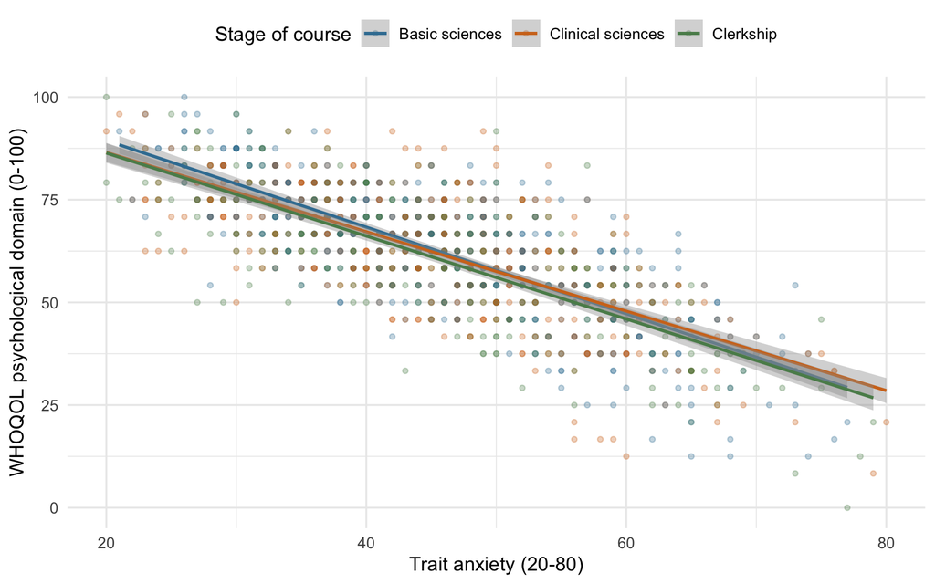

Figure 1. Psychological quality of life against trait anxiety, by stage of the course. Points are individual students; lines are linear smoothers.

Psychological quality of life falls steeply and near-linearly as trait anxiety rises, and the three stages of the course lie almost on top of one another, suggesting the stage of the course matters little once anxiety is accounted for.

## Univariable models

**Univariable linear regression.**

| **Characteristic** | **Beta** | **95% CI** | **p-value** |
| --- | --- | --- | --- |
| Sex |  |  |  |
| Female | — | — |  |
| Male | 4.6 | 3.0, 6.3 | <0.001 |
| Stage of course |  |  |  |
| Basic sciences | — | — |  |
| Clinical sciences | 0.17 | -1.8, 2.2 | 0.9 |
| Clerkship | -1.2 | -3.3, 0.92 | 0.3 |
| Age (years) | -0.10 | -0.38, 0.18 | 0.5 |
| Resilience score (16-98) | 0.80 | 0.74, 0.85 | <0.001 |
| DREEM global score (0-200) | 0.28 | 0.26, 0.31 | <0.001 |
| State anxiety (20-80) | -0.86 | -0.91, -0.80 | <0.001 |
| Trait anxiety (20-80) | -1.0 | -1.1, -0.96 | <0.001 |

Abbreviation: CI = Confidence Interval

## Multivariable model

**Multivariable linear regression.**

| **Characteristic** | **Beta** | **95% CI** | **p-value** |
| --- | --- | --- | --- |
| Sex |  |  |  |
| Female | — | — |  |
| Male | 0.61 | -0.42, 1.6 | 0.2 |
| Stage of course |  |  |  |
| Basic sciences | — | — |  |
| Clinical sciences | 0.05 | -1.2, 1.3 | >0.9 |
| Clerkship | -0.19 | -1.7, 1.3 | 0.8 |
| Age (years) | -0.25 | -0.45, -0.06 | 0.011 |
| Resilience score (16-98) | 0.31 | 0.26, 0.37 | <0.001 |
| DREEM global score (0-200) | 0.06 | 0.04, 0.08 | <0.001 |
| State anxiety (20-80) | -0.24 | -0.30, -0.17 | <0.001 |
| Trait anxiety (20-80) | -0.58 | -0.65, -0.51 | <0.001 |

Abbreviation: CI = Confidence Interval

**Model fit**

| Statistic | Value |
| --- | --- |
| R-squared | 0.646 |
| Adjusted R-squared | 0.644 |
| Residual SE | 9.37 |
| n | 1350 |
| Model df | 8 |

The model explains 64.6% of the variance in psychological quality of life (adjusted R-squared 0.644), which is very high for cross-sectional questionnaire data and is a warning in itself (see Discussion). Holding the other six predictors fixed, each additional point of trait anxiety is associated with a -0.58 (95% CI -0.65 to -0.51)-point change in the WHOQOL psychological score, and each point of state anxiety with -0.24 (95% CI -0.30 to -0.17). Resilience remains independently associated in the expected direction (0.31 (95% CI 0.26 to 0.37) points per point), as does the DREEM global score (0.06 (95% CI 0.04 to 0.08) points per point, so roughly 1.2 points across a 20-point difference in perceived environment). Age is associated with a small decrement (-0.25 (95% CI -0.45 to -0.06) points per year) once stage of the course is held fixed, while sex and stage of the course show no independent association. These are conditional associations in a cross-sectional survey, not effects of intervening on anxiety or resilience.

## Unadjusted versus adjusted

**Table 2. Unadjusted and adjusted estimates.**

| **Characteristic** | **Unadjusted** **Beta** | **Unadjusted** **95% CI** | **Unadjusted** **p-value** | **Adjusted** **Beta** | **Adjusted** **95% CI** | **Adjusted** **p-value** |
| --- | --- | --- | --- | --- | --- | --- |
| Sex |  |  |  |  |  |  |
| Female | — | — |  | — | — |  |
| Male | 4.6 | 3.0, 6.3 | <0.001 | 0.61 | -0.42, 1.6 | 0.2 |
| Stage of course |  |  |  |  |  |  |
| Basic sciences | — | — |  | — | — |  |
| Clinical sciences | 0.17 | -1.8, 2.2 | 0.9 | 0.05 | -1.2, 1.3 | >0.9 |
| Clerkship | -1.2 | -3.3, 0.92 | 0.3 | -0.19 | -1.7, 1.3 | 0.8 |
| Age (years) | -0.10 | -0.38, 0.18 | 0.5 | -0.25 | -0.45, -0.06 | 0.011 |
| Resilience score (16-98) | 0.80 | 0.74, 0.85 | <0.001 | 0.31 | 0.26, 0.37 | <0.001 |
| DREEM global score (0-200) | 0.28 | 0.26, 0.31 | <0.001 | 0.06 | 0.04, 0.08 | <0.001 |
| State anxiety (20-80) | -0.86 | -0.91, -0.80 | <0.001 | -0.24 | -0.30, -0.17 | <0.001 |
| Trait anxiety (20-80) | -1.0 | -1.1, -0.96 | <0.001 | -0.58 | -0.65, -0.51 | <0.001 |

Abbreviation: CI = Confidence Interval

Almost every estimate shrinks toward the null, and the size of the shrinkage ranks the predictors. **Trait anxiety** retains the most, falling from -1.01 crude to -0.58 adjusted (57% of its crude size) - the signature of the dominant predictor in the set. **Resilience** keeps only 39% (0.80 to 0.31), because much of what the resilience scale captures is simply low trait anxiety. **State anxiety** keeps 27% (-0.86 to -0.24) for the same reason: it and trait anxiety are largely measuring one negative-affect disposition. The **DREEM global score** collapses hardest, from 0.282 to 0.061 per point (22% retained); its crude association was mostly a proxy for the anxiety and resilience of the student doing the rating.

Two coefficients change significance, in opposite directions. **Sex** is a strong crude predictor - men score 4.62 points higher, p < 0.001 - but the adjusted difference is 0.61 points and non-significant (p = 0.25): the crude male advantage in psychological quality of life is entirely explained by women in this sample scoring higher on both anxiety scales. **Age** moves the other way - crude -0.10 and non-significant (p = 0.47), adjusted -0.25 and significant (p = 0.011) - a suppression effect that appears once stage of the course is held fixed, because within a given stage the older students are those who entered late or are repeating. **Stage of the course** barely moves and stays non-significant throughout (clerkship -1.19 crude versus -0.19 adjusted).

## Diagnostics

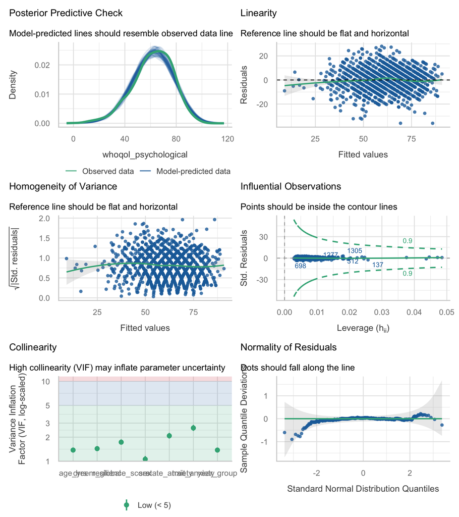

**Variance inflation factors**

| Term | VIF | Tolerance |
| --- | --- | --- |
| sex | 1.06 | 0.944 |
| year_group | 1.38 | 0.726 |
| age_yrs | 1.38 | 0.725 |
| resilience_score | 1.73 | 0.578 |
| dreem_global | 1.44 | 0.696 |
| state_anxiety | 2.08 | 0.481 |
| trait_anxiety | 2.61 | 0.384 |

**HC3 robust standard errors (sensitivity check)**

| term | estimate | robust SE | statistic | p.value |
| --- | --- | --- | --- | --- |
| (Intercept) | 71.999 | 4.336 | 16.61 | <0.001 |
| sexMale | 0.608 | 0.531 | 1.15 | 0.2521 |
| year_groupClinical sciences | 0.052 | 0.643 | 0.08 | 0.9353 |
| year_groupClerkship | -0.194 | 0.770 | -0.25 | 0.8010 |
| age_yrs | -0.254 | 0.108 | -2.36 | 0.0186 |
| resilience_score | 0.313 | 0.028 | 11.02 | <0.001 |
| dreem_global | 0.061 | 0.012 | 5.21 | <0.001 |
| state_anxiety | -0.235 | 0.033 | -7.14 | <0.001 |
| trait_anxiety | -0.580 | 0.036 | -16.07 | <0.001 |

The robust standard errors are within a few percent of the model-based ones and no conclusion changes, so the heteroscedasticity is not consequential here.

**Influential points.** No observation exceeds the Cook’s distance threshold; the largest Cook’s distance is 0.018, far below 0.5. No single student drives the results.

# Discussion

**Limitations.** *Construct overlap is the central problem.* The WHOQOL psychological domain contains items on negative feelings and self-esteem, and the trait anxiety scale contains items on the same feelings; an R-squared of 0.65 reflects partly shared item content, not only a substantive relationship. The trait-anxiety coefficient should be read as “students who describe themselves as anxious also describe themselves as having poor psychological wellbeing”, which is close to a tautology. *Clustering is not modelled.* Students were sampled from 22 medical schools, but the released file carries no school identifier, only `school_legal_status` and `school_location`; students within a school share teachers, curriculum and city, so the true standard errors are wider than those reported and no random intercept can be fitted. *Cross-sectional design.* Anxiety, resilience and quality of life were measured on the same day by the same instrument; the direction of the arrow between them cannot be established, and reverse causation (poor quality of life raising anxiety) is at least as plausible as the direction implied by the model. *Common-method bias.* Every variable except sex, age and the two school characteristics is self-reported on one questionnaire, so a student’s general negativity inflates all associations at once. *No missing data* is a genuine strength here - all 1350 rows were analysed.

**Future work.** A longitudinal design that measures trait anxiety at entry and quality of life a year later, with school identifiers retained so that between-school variation can be separated from between-student variation.

# Feasibility notes

*Not part of a student report.*